# STAT340 Lecture 6: Exploratory Data Analysis and unsupervised learning

**Readings:** ISLR Sections 12.1, 12.2 and 12.4

So far in this course (and in most of your courses, probably), you have been given a data set along with a particular estimation or testing problem.

**Example:** someone hands you the results of an experiment and asks you to perform a t-test.

In this lecture, we will consider the broader (and arguably more challenging) task of *exploratory data analysis* (EDA) and the related task of *unsupervised learning*.

**Example:** You collect the tweets from a group of twitter users affiliated with the R and Python communities. At this stage, we don’t even quite know what is the “right” statistical question to ask. We are at the more primitive stage of “exploring” the data, just to see what it is like. **How should we go about this?**

**Example:** We gather a large collection of unlabeled images from a database (the machine learning literature has many of these). The images are of different kinds of animals (cats, dogs, birds, goats…), but we do not have labels that tell us which images have which animals. That is, our data set is *unlabeled*. **What can we do without “supervisory information”?**

## Learning objectives

After this lesson, you will be able to

- Discuss the basic ideas behind EDA and its importance and apply some basic EDA techniques related to exploratory plotting
- Explain the concept of unsupervised learning and explain how it differs from supervised learning (i.e., from prediction problems)
- Explain the concept of dimensionality reduction and why it can be useful
- Use R to apply PCA to data
- Explain the concept of clustering and why it can be useful
- Use R to cluster data using k-means or hierarchical clustering

## Why do exploratory data analysis?

When we get a data set, it is often very tempting to jump right away to doing statistical testing or estimation.

For example, here is a data set that shows how BMI relates to the number of steps taken per day for a group of subjects, split by biological sex.

```r
# bmi_data.csv is in the zip file of additional files
# associated with this lecture, available on the course webpage
# https://kdlevin-uwstat.github.io/STAT340-Fall2021/lectures/
bmi_data <- read.csv('bmi_data.csv', header=TRUE)
head(bmi_data)
```

```
##   steps  bmi Sex
## 1  2569 25.9   M
## 2  6528 29.3   F
## 3  7731 26.5   M
## 4 11829 29.7   M
## 5 12894 22.2   F
## 6  9097 29.2   M
```

Well, why not, we could throw a linear model at this, or fit two different models for male and female or…

It’s tempting to dive right in, I know.

But wait. Let’s just plot the data, first.

After all, at the risk of repeating myself, **Always plot your data.**

[figure not shown]

```r
pp <- ggplot(bmi_data, aes(x=steps, y=bmi))
pp <- pp + geom_point(aes(color=Sex), size=0.5)
pp
```

Huh. Well, that’s interesting.

This was actually part of a (somewhat cruel?) experiment to see how beginner data scientists approached analysis when given a specific hypothesis to test versus when they were simply given a data set and encouraged to explore. See [here.](https://genomebiology.biomedcentral.com/articles/10.1186/s13059-020-02133-w)

Students who were given a particular hypothesis to test were far less likely to see the gorilla!

We promise that we will not play such a prank on you in a homework or exam.

But this illustrates an important lesson: **always look at your data.**

More generally, EDA is often the first step toward identifying interesting structure in your data.

## “Day science” vs “Night science”

EDA is less a set of tools than it is a state of mind.

To illustrate this, consider the concepts of “day science” and “night science” (coined by Francois Jacob; see [here](https://genomebiology.biomedcentral.com/articles/10.1186/s13059-019-1800-6) for background).

**Day science** is the kind of research you are probably most familiar with. It proceeds step-wise:

1. State a hypothesis
2. Develop an experiment
3. Conduct the experiment
4. Analyze the results

This is contrasted with the more free-wheeling and exploratory **night science**, in which we explore the space of possible hypotheses and conduct experiments that do not necessarily test a specific hypothesis.

These two different modes of science map very nicely onto the statistics that you have mostly been taught in your classes so far (day science; we specify a null hypothesis, set up a test, etc) and the basic idea of exploratory data analysis (night science; poke around and see what we find).

## Data Visualization

Undeniably the most fundamental tool in the EDA toolkit is data visualization. The easiest way to find interesting patterns in your data is to just look at it!

Importantly, there are often things that are easy to see using visualization that are not easily captured by summary statistics.

The best example of this (albeit an extreme one), is [Anscombe’s quartet](https://en.wikipedia.org/wiki/Anscombe's_quartet).

This is a set of four data sets constructed by Francis Anscombe, and it’s fundamental enough that it’s included in R.

```r
data(anscombe) # Load the data set
head(anscombe) # Let's just see what our variables are, to start with.
```

```
##   x1 x2 x3 x4   y1   y2    y3   y4
## 1 10 10 10  8 8.04 9.14  7.46 6.58
## 2  8  8  8  8 6.95 8.14  6.77 5.76
## 3 13 13 13  8 7.58 8.74 12.74 7.71
## 4  9  9  9  8 8.81 8.77  7.11 8.84
## 5 11 11 11  8 8.33 9.26  7.81 8.47
## 6 14 14 14  8 9.96 8.10  8.84 7.04
```

Okay, this needs a bit of explanation.

Anscombe’s quartet is technically a collection of four data sets (hence the “quartet” part). These are given by the pairs `(x1,y1)`, `(x2,y2)`, etc.

Now, let’s try computing some basic statistics. Why not start with the mean?

```r
colMeans(anscombe)
```

```
##       x1       x2       x3       x4       y1       y2       y3       y4
## 9.000000 9.000000 9.000000 9.000000 7.500909 7.500909 7.500000 7.500909
```

So, all four data sets have the same mean in both `x` and `y` (at least to several decimal places).

How about standard deviations?

```r
sapply(anscombe, sd)
```

```
##       x1       x2       x3       x4       y1       y2       y3       y4
## 3.316625 3.316625 3.316625 3.316625 2.031568 2.031657 2.030424 2.030579
```

Again, all pretty much the same…

How about correlations between `x` and `y`?

```r
c( cor( anscombe$x1, anscombe$y1 ),
   cor( anscombe$x2, anscombe$y2 ),
   cor( anscombe$x3, anscombe$y3 ),
   cor( anscombe$x4, anscombe$y4 ) )
```

```
## [1] 0.8164205 0.8162365 0.8162867 0.8165214
```

```r
lm( x1 ~ 1+ y1, anscombe )
```

```
##
## Call:
## lm(formula = x1 ~ 1 + y1, data = anscombe)
##
## Coefficients:
## (Intercept)           y1
##     -0.9975       1.3328
```

```r
lm( x2 ~ 1+ y2, anscombe )
```

```
##
## Call:
## lm(formula = x2 ~ 1 + y2, data = anscombe)
##
## Coefficients:
## (Intercept)           y2
##     -0.9948       1.3325
```

```r
lm( x3 ~ 1+ y3, anscombe )
```

```
##
## Call:
## lm(formula = x3 ~ 1 + y3, data = anscombe)
##
## Coefficients:
## (Intercept)           y3
##      -1.000        1.333
```

```r
lm( x4 ~ 1+ y4, anscombe )
```

```
##
## Call:
## lm(formula = x4 ~ 1 + y4, data = anscombe)
##
## Coefficients:
## (Intercept)           y4
##      -1.004        1.334
```

Yet again, remarkably similar intercepts and coefficients!

At this point, it seems reasonable to conclude that these data sets must be remarkably similar to one another.

But let’s plot the data, just to be sure.

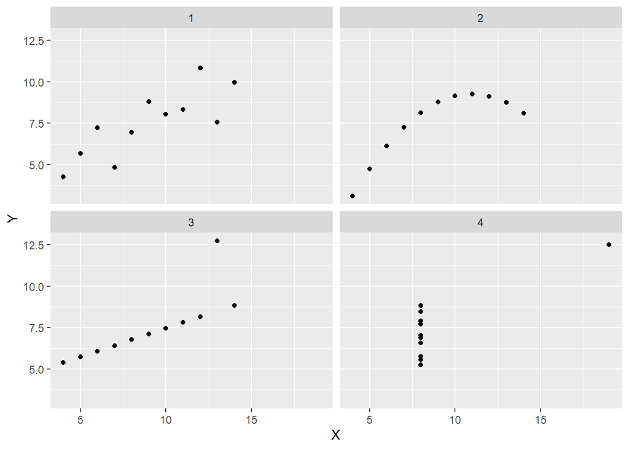

```r
# We need to do a bit of rearranging first, so we can use ggplot2 easily
# As usual, there are nicer and/or more clever  ways to do this,
# but we're doing it this way because it's easy to read/understand
xx <- c( anscombe$x1, anscombe$x2, anscombe$x3, anscombe$x4 )
yy <- c( anscombe$y1, anscombe$y2, anscombe$y3, anscombe$y4 )
sets <- rep( c(1,2,3,4), each=nrow(anscombe))
df_anscombe <- data.frame('X'=xx, 'Y'=yy, 'Set'=sets)

pp <- ggplot(df_anscombe, aes(x=X, y=Y))
pp <- pp + geom_point()
pp <- pp + facet_wrap(~Set)

pp
```

Wow, those are… quite different!

Lesson learned! Visualization can identify patterns that you may not find by just fitting models and looking at summary statistics!

Your previous courses (especially STAT240) should have given you a broad exposure to `ggplot2` and related visualization tools in R, so we won’t rehash those now.

If you need a refresher, or if you want to learn more about `ggplot2`, Hadley Wickham’s book is the gold standard: https://ggplot2-book.org/

If you want to learn more about data visualization, the classic textbook is *The Visual Display of Quantitative Information* by Edward Tufte. Better yet, take Kris Sankaran’s visualization course!

## Dimensionality reduction

We saw above the importance of visualizing our data for the purposes of exploration.

This is all well and good when our data has only a few variables. That is, when our data is *low-dimensional*.

What if our data is more complicated?

#### Example: text data

In natural language processing, we are often interested in analyzing collections of text.

For example, our data might take the form of a large collection of books, and we might be interested in examining how different authors or different genres differ in their word usage.

Data of this sort are commonly represented by their word counts. A document (e.g., a book) is represented by a vector, whose entries correspond to words.

So there is an entry in this vector for the word “dog”, an entry for the word “cat”, an entry for the word “watermelon”, etc. One entry for every word in our collection of documents.

The result is that each document gets represented by a really long vector of word counts.

The problem arises when we try to visualize this data.

There are something like 600,000 words in the English language. So each document in our collection is represented by a vector with thousands of entries!

### Solution: reduce the number of dimensions

I myself have a hard enough time imagining 4-dimensional space. How on earth are we going to visualize 1000-dimensional space?!

What we would like is a way to map our data down to fewer dimensions, but do so in such a way that preserves the structure of our data.

This task is called *dimensionality reduction*.

There are lots of different dimensionality reduction methods out there. Let’s just discuss one today to give you the basic idea.

Principal components analysis (PCA) is undoutbedly the most popular dimensionality reduction method out there, so let’s discuss that.

Let’s start with an easy case: suppose that we want to reduce two dimensions down to one dimension. Here’s some two-dimensional data.

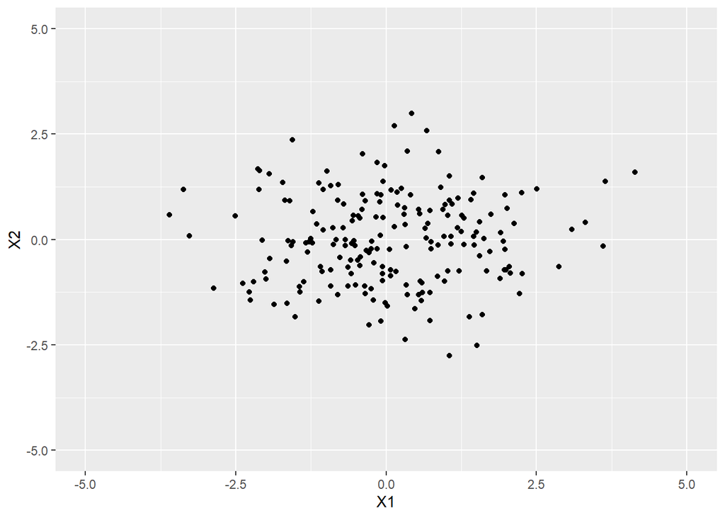

```r
require(ggplot2)
source('dimred_demo.R') # Contains a data frame demo_df_1, which we'll plot

pp <- ggplot( demo_df_1, aes(x=X1, y=X2) ) + geom_point()
pp <- pp + xlim(-5,5) + ylim(-5,5)
pp
```

**Note:** For our sanity, let’s assume that the data has been centered at zero. In practice, centering the data (i.e., subtracting out the mean) is a required preprocessing step to prepare data for PCA anyway, so this isn’t a big leap to make.

Now, suppose that we can only afford to work with one dimension, not two. Of course this is silly, but in the really high-dimensional case, this is essentially why we do dimensionality reduction!

How do we represent this data in one dimension instead of two, while minimizing the amount of information that we throw away?

We want to reduce our data down to one dimension. What that really means is choosing a line (i.e., a direction), and projecting our data onto that line.

In linear regression, we choose a line through the data that minimizes the sum of the squared residuals (i.e., minimizes the squared errors).

Something like this:

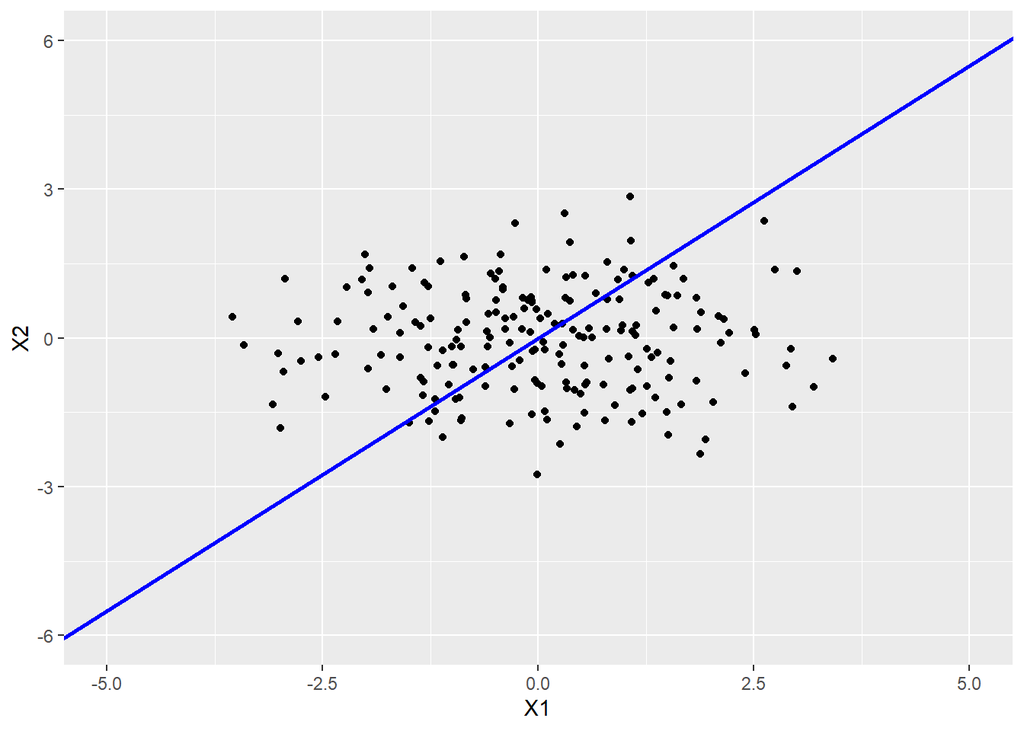

```r
source('dimred_demo.R') # Contains a data frame demo_df_1, which we'll plot

# Plot the data again
pp <- ggplot( demo_df_1, aes(x=X1, y=X2) ) + geom_point()
pp <- pp + xlim(-5,5) + ylim(-6,6)

# Pick a line. How about y= 1.1 x.
slope <- 1.1
# Plot that line
pp <- pp + geom_abline(intercept=0, slope=slope, color='blue', size=1)
pp
```

So if we’re regressing `X2` against `X1`, the linear regression residuals are just the vertical distances to this line. Let’s plot them.

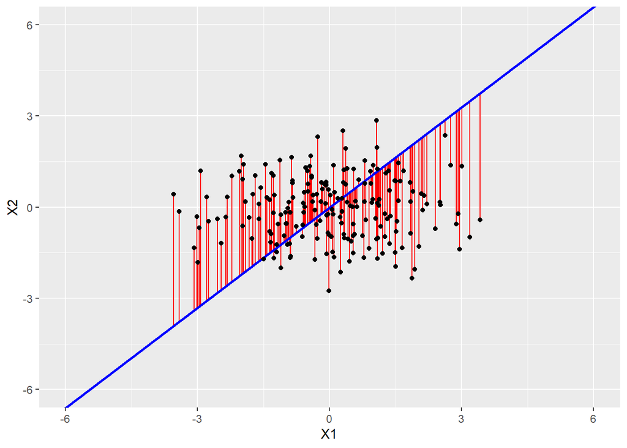

```r
# Same plotting, but now use geom_segment to draw residuals.
# call geom_point and abline again to put points on top of resid lines.
pp <- ggplot( demo_df_1, aes(x=X1, y=X2) )
pp <- pp + geom_segment(aes(x=X1,xend=X1, y=slope*X1, yend=X2 ), color='red') + geom_abline(intercept=0, slope=slope, color='blue', size=1) + geom_point()
pp <- pp + xlim(-6,6) + ylim(-6,6)
pp
```

In regression, we play around with the slope of that line to minimize the sum of the squared lengths of the vertical residuals.

We look at the vertical residuals because in regression, `Y` and `X` are fundamentally different. `Y` is a function of `X`.

In PCA, all of our data dimensions are, in a sense, the same. So vertical residuals don’t make much sense.

Instead, we are going to try and minimize the squared *reconstruction error* of the data, as measured by the distance from each data point to its projection onto the line. That’s easiest to see in a plot.

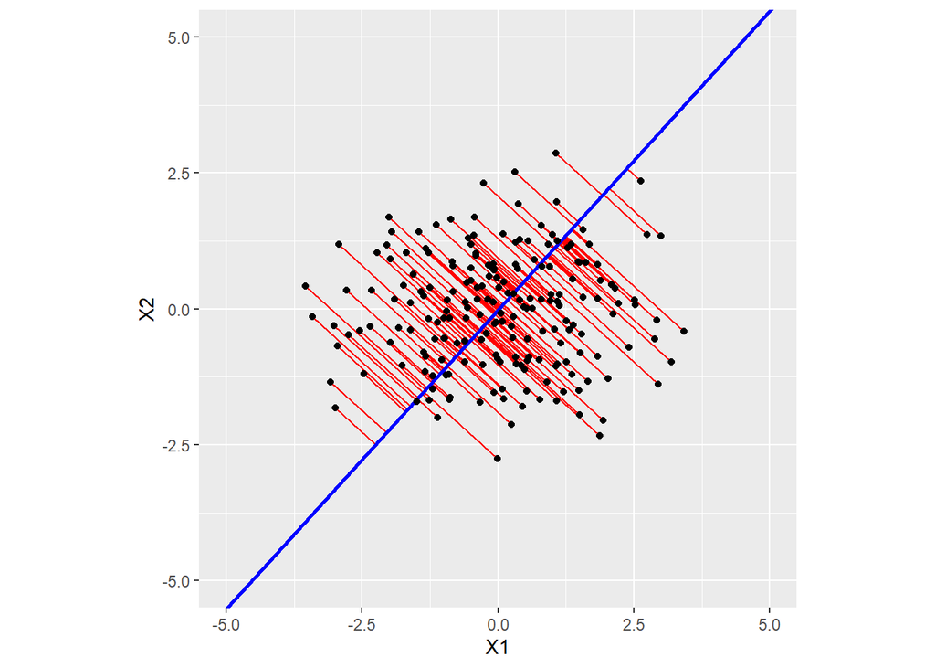

```r
# Pick a line. How about y= 1.1 x.
slope <- 1.1

# Project the points onto that line.
# If you've taken linear algebra, you know that there is a more clever way
# to do this, but since linear algebra isn't a prereq,
# we'll use the high school algebra way.
# Remember that the projection of a point (x,y) onto a 2-D line y = m*x + b
# is given by
#
pp <- ggplot( demo_df_1, aes(x=X1, y=X2) )
pp <- pp + geom_segment(aes(x=X1,xend=(X1+slope*X2)/(1+slope^2),
                            y=X2, yend=slope*(X1+slope*X2)/(1+slope^2) ), color='red') + geom_abline(intercept=0, slope=slope, color='blue', size=1) + geom_point()
pp <- pp + xlim(-5,5) + ylim(-5,5)
# Make sure aspect ratio is 1 so we can see the projections correctly!
pp <- pp + theme(aspect.ratio=1)
pp
```

So we are still trying to choose a line that minimizes a sum of squared errors, but we are no longer letting the `Y` dimension be “special”.

More importantly, just like in linear regression, there is a (relatively) easy solution to this problem. Unfortunately, that solution involves linear algebra, so it’s outside the scope of our course.

### PCA: more dimensions

So we just saw that PCA projects two-dimensional data down to one dimension by choosing the line that minimizes the squared reconstruction error between the data and the projection of the data onto the line.

What if our data is bigger than two-dimensional (which, let’s face it, it usually is)?

Well, not much changes! To project $d$-dimensional data down to one dimension, we are going to choose the line (i.e., a direction; a vector) that minimizes the reconstruction error between the data and the projections onto that vector.

The basic linear algebraic trick for finding that “best reconstruction error” direction is also the same (but still outside the scope of the course because not everyone in our class has taken linear algebra).

Now, here’s the kicker. What if instead of just condensing our data down to one dimension, we want two dimensions, or three or four or?…

After all, we do dimensionality reduction to save space and/or processing time, but it’s not like our computers are so slow that we can only process one-dimensional data.

So, let’s say we want to best summarize our data with $k$ dimensions.

In this case, “choose the line that gives the best reconstruction error” becomes “choose the $k$-dimensional hyperplane that gives the best reconstruction error”, and lucky for us, the same basic linear algebraic tricks *still* give us a solution!

### PCA another way: maximizing variance

In our notes above, we saw the “minimize the squared error” interpretation, but let’s see another.

Let’s go back to our nice simple two-dimensional data case.

Intuitively, we want to project our data from two dimensions down to one in such a way that we preserve as much information as possible about our data.

How do we do that?

Well, roughly speaking, “more information” means “higher variance”. So we can try to find the direction such that projecting our data onto that direction has the highest variance. Section 12.2.1 of ISLR describes this in a bit more detail.

### PCA in R: `prcomp`

PCA is implemented in R by the `prcomp` function.

You pass it a data matrix (or a data frame), and it outputs some information about the principal components that it finds.

`prcomp` just computes all of the principal components– it’s our job to choose how many to keep. This problem of choosing the number of dimensions $k$ is a bit of a black art, but we’ll revisit it later in the semester.

Let’s quickly look at applying PCA to the famous US arrests data (this is also the data set used as a demo in ISLR). This data set captures violent crime rates in each of the fifty US states.

```r
data(USArrests)
head(USArrests)
```

```
##            Murder Assault UrbanPop Rape
## Alabama      13.2     236       58 21.2
## Alaska       10.0     263       48 44.5
## Arizona       8.1     294       80 31.0
## Arkansas      8.8     190       50 19.5
## California    9.0     276       91 40.6
## Colorado      7.9     204       78 38.7
```

Okay, so we have four dimensions, measured for each of the 50 states.

```r
prcomp(USArrests, scale=TRUE) # See below for discussion of importance of scaling
```

```
## Standard deviations (1, .., p=4):
## [1] 1.5748783 0.9948694 0.5971291 0.4164494
##
## Rotation (n x k) = (4 x 4):
##                 PC1        PC2        PC3         PC4
## Murder   -0.5358995  0.4181809 -0.3412327  0.64922780
## Assault  -0.5831836  0.1879856 -0.2681484 -0.74340748
## UrbanPop -0.2781909 -0.8728062 -0.3780158  0.13387773
## Rape     -0.5434321 -0.1673186  0.8177779  0.08902432
```

The entries in each column of that output are called the *loadings* of the variables. Each column of the output is a unit-norm vector (so the squared loadings sum to 1 in each column). This vector points in the direction of the principal component.

Roughly speaking, the loadings capture how much each of our original variables contribute to the principal component direction.

For example, we see that in the `USArrests` data, the three violent crime rates all have similarly large loadings on the first principal component, while the `UrbanPop` variable has a smaller loading. This captures the fact that the three crime rates are correlated with one another.

A useful tool for visualizing PCA components is a kind of plot called a `biplot`. Once again, because this is a fundamental tool, it’s built into R and easy to use.

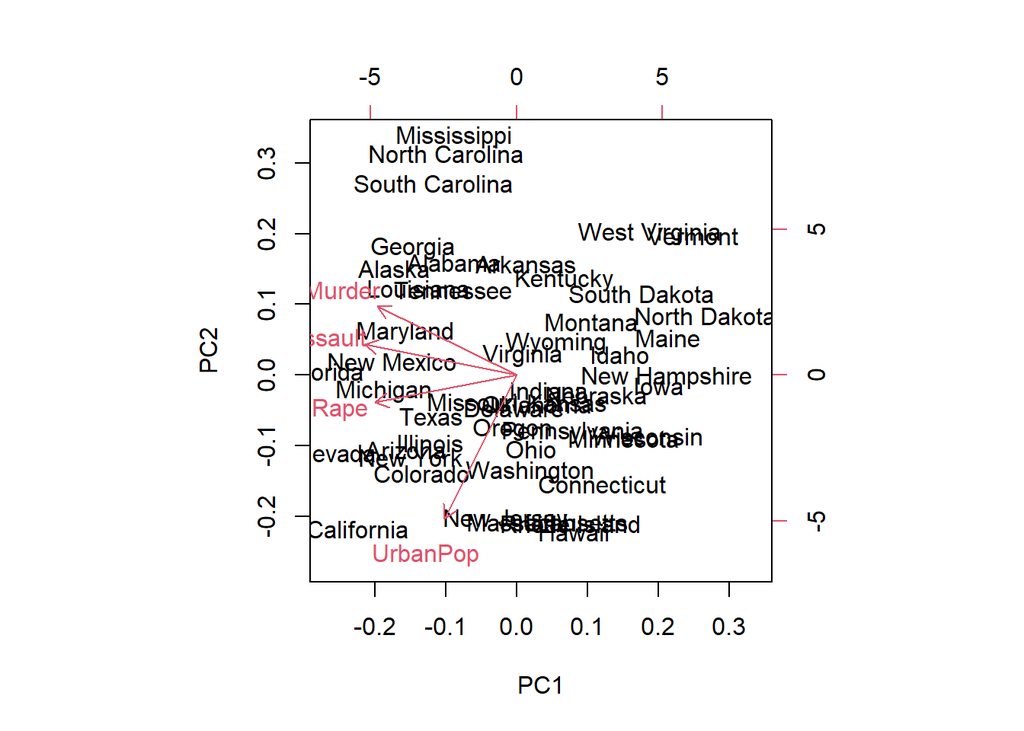

```r
biplot( prcomp(USArrests, scale=TRUE) )
```

Okay, not the prettiest graphic. For that, see the `ggbiplot` package, which uses `ggplot2`-style plotting for biplots.

Nonetheless, the idea here is that we have two different pieces of geometric information in a single plot.

1. We have our data points, displayed in black in two-dimensional space. Remember, our original data here was four-dimensional, so we are looking at the “dimension reduced” data. These two dimensions are exactly the first two principal component directions.
2. The loadings of the first two principal components are indicated in red. Again, we are showing the first two PC directions, so there are two loadings (one for each PC directionn) for each of the four original variables, hence four red vectors (one vector requires two values: and `x` and a `y`).

What the red loading vectors show us is an indication of how our variables tend to correlate. For example, the three crime types all have their loadings pointed in similar directions, indicating that they are correlated with one another.

See ISLR Figure 12.1 for a nicer-looking version of this plot and a longer discussion of biplots and how to read them.

### Caution: PCA and scaling

One important cautionary note. Consider a (fictional) data set that gives income as a function of years of schooling.

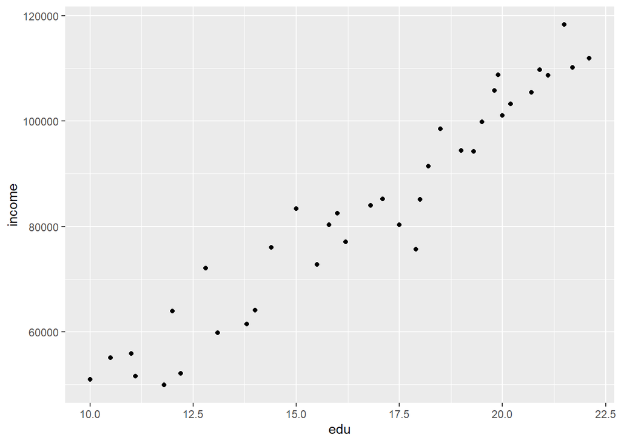

```r
source('dimred_demo.R') # Contains datafram income_v_edu,
# Loosely based on figure 2.2 in ISLR.

pp <- ggplot(income_v_edu, aes(x=edu, y=income)) + geom_point()
pp
```

If we naively apply PCA to this data, something weird happens:

```r
prcomp(income_v_edu) # Note lack of scaling, here!
```

```
## Standard deviations (1, .., p=2):
## [1] 2.052256e+04 9.434351e-01
##
## Rotation (n x k) = (2 x 2):
##                PC1          PC2
## income 0.999999986 -0.000170117
## edu    0.000170117  0.999999986
```

The loadings are essentially equal to zero and one! This is because the scale of the data is inappropriate.

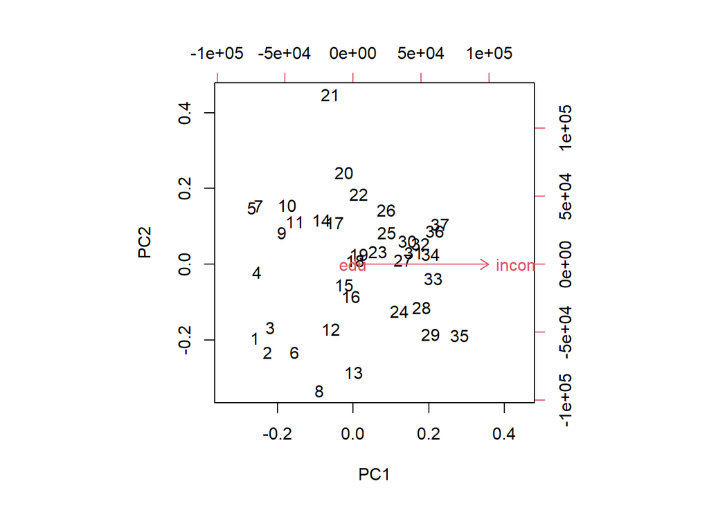

```r
biplot( prcomp(income_v_edu) )
```

When applying PCA, it is important to rescale the variables so that they all have (approximately) the same standard deviation. If we don’t do that, variables with “larger” scales will eat up all the variance, and we won’t find any interesting structure!

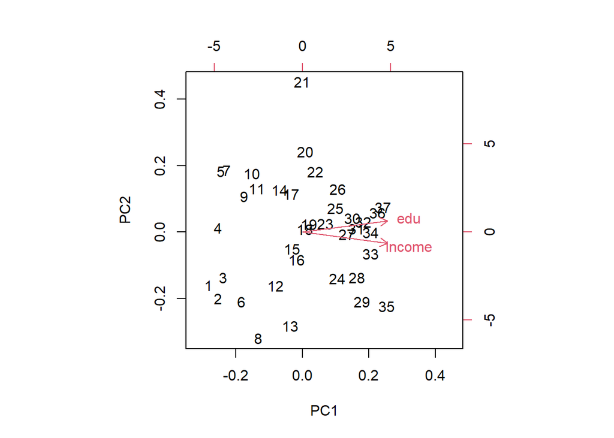

```r
biplot( prcomp(income_v_edu, scale=TRUE ) )
```

The loadings point in the same direction, indicating that income and education are highly correlated (as we already knew because the data set was so simple).